# Lab 02 - Multiple Linear Regression

## 2.1 Forma Matriciale

In forma matriciale, estesa per p beta parametri, il modello viene scritto come segue:

$$\begin{bmatrix}
Y_1 \\
Y_2 \\
\vdots\\
Y_n \\
\end{bmatrix}
=
\begin{bmatrix}
1 & x_{11} & x_{12} & \cdots & x_{1(p-1)} \\
1 & x_{21} & x_{22} & \cdots & x_{2(p-1)} \\
\vdots & \vdots & \vdots & & \vdots \\
1 & x_{n1} & x_{n2} & \cdots & x_{n(p-1)} \\
\end{bmatrix}
\begin{bmatrix}
\beta_0 \\
\beta_1 \\
\beta_2 \\
\vdots \\
\beta_{p-1} \\
\end{bmatrix}
+
\begin{bmatrix}
\epsilon_1 \\
\epsilon_2 \\
\vdots\\
\epsilon_n \\
\end{bmatrix}
= X \beta + \epsilon,$$

La matrice $X$ è quindi:

$$X = \begin{bmatrix}
1 & wt_{1} & year_{1} \\
1 & wt_{2} & year_{2} \\
\vdots & \vdots & \vdots \\
1 & wt_{n} & year_{n} \\
\end{bmatrix}$$

- Prima colonna, valori di `intercept`
- Seconda colonna, valor di `wt`
- Terza colonna, valori di `year`

## 2.2 Inferenza sui parametri

Iniziamo dal creare la matrice $X$.

```r
# Rows number
n <- nrow(autompg)
# Creates the design matrix
X <- cbind(rep(1,n), autompg$wt, autompg$year)
```

### 2.2.1 La stima di $\beta$

La stima puntuale di $\beta$ viene derivata con:

$$\hat{\beta} = (X^{T}
X)^{-1}X^{T}y$$

```r
# observed y
y <- autompg$mpg

# beta estimates
(beta_hat <- as.vector(solve(t(X) %*% X) %*% t(X) %*% y))
```

```
## [1] -14.637641945  -0.006634876   0.761401955
```

```r
coef(fit)
```

```
##   (Intercept)            wt          year
## -14.637641945  -0.006634876   0.761401955
```

[Bonus question: i valori stimati corrispondono ai valori che minimizzano i quadrati dei residui? Si scriva una funzione che valuti il valore dell’errore quadratico medio campionario per diversi valori di $\boldsymbol{\beta}$ e si verifichi se il valori stimati minimizzano l’errore quadratico medio.]

### 2.2.2 Inferenza sulla normalita’

Dato che assumiamo che $\varepsilon$ segua una distribuzione normale, di conseguenza assumiamo anche $Y|X$ segua una distribuzione normale e che le osservazioni $(y_i, \ldots, y_n)$ siano una realizzazione della variabile casuale: $(Y|X=x) \sim N(X \beta, \sigma^2 I_n)$ e ne consegue che $\hat{\beta}$ segua una normale con media e varianza:

$$E[\hat{\beta}] = \beta \quad \text{and}
\quad V[\hat{\beta}] = \sigma^2 (X^T X)^{-1}$$

Dato che $\sigma^2$ non è noto viene stimato con:
$$s^2_e =
\frac{\sum_{i=1}^{n}(y_i - \hat{y}_i)^2}{n-p} = \frac{\sum_{i=1}^{n}e^T
e }{n-p}$$
dove $e$ è il vettore degli errori del modello.

Troviamo or $s_e$

```r
# Manually
(est_sigma <- sqrt(sum(fit$residuals^2)/(n-length(fit$coef))))
```

```
## [1] 3.431367
```

```r
# (est_sigma <- sqrt(sum(residuals(fit)^2)/(n-length(beta_hat))))

# lm model
summary(fit)$sigma
```

```
## [1] 3.431367
```

E procediamo a stimare i coefficienti

```r
(se_beta_hat <- as.vector(est_sigma * sqrt(diag(solve(t(X) %*% X)))))
```

```
## [1] 4.0233913563 0.0002148504 0.0497265950
```

```r
summary(fit)$coef[,2]
```

```
##  (Intercept)           wt         year
## 4.0233913563 0.0002148504 0.0497265950
```

Anche questo processo minimizza la somma dei residui

```r
#Resid
resid <- (autompg$mpg - X %*% beta_hat)

head(residuals(fit))
```

```
## 8 cylinder 70 chevrolet chevelle malibu         8 cylinder 70 buick skylark 320
##                               2.5881102                               0.8421017
##        8 cylinder 70 plymouth satellite             8 cylinder 70 amc rebel sst
##                               2.1369386                               0.1170340
##               8 cylinder 70 ford torino          8 cylinder 70 ford galaxie 500
##                               1.2231920                               5.1415013
```

```r
head(resid)
```

```
##           [,1]
## [1,] 2.5881102
## [2,] 0.8421017
## [3,] 2.1369386
## [4,] 0.1170340
## [5,] 1.2231920
## [6,] 5.1415013
```

```r
# Per qualunque valore di (beta0, beta1, beta2) MSE > MSE(beta_hat)
sum(resid^2)
```

```
## [1] 4556.646
```

```r
# Se proviamo questo, sara' piu' alto del MSE
sum(((autompg$mpg - X %*% c(-16, 0.06, 0.67)))^2)
```

```
## [1] 15381230
```

Possiamo derivare anche l’intera matrice di varianza covarianza di $\beta$:

```r
#variance-covariance matrix
# The main diagonal represents the variance for each beta_{j}
(est_sigma^2) * (solve(t(X) %*% X))
```

```
##               [,1]          [,2]          [,3]
## [1,] 16.1876780057 -3.862527e-04 -1.975715e-01
## [2,] -0.0003862527  4.616070e-08  3.274060e-06
## [3,] -0.1975715338  3.274060e-06  2.472734e-03
```

```r
vcov(fit)
```

```
##               (Intercept)            wt          year
## (Intercept) 16.1876780057 -3.862527e-04 -1.975715e-01
## wt          -0.0003862527  4.616070e-08  3.274060e-06
## year        -0.1975715338  3.274060e-06  2.472734e-03
```

I valori della covarianza sono a volte difficili da interpretare e può essere comodo derivare la matrice di correlazione tramite la funzione `cov2cor` per valutare la correlazione tra la stima dei parametri e l’incertezza nella stima:

```r
cov2cor(vcov(fit))
```

```
##             (Intercept)         wt       year
## (Intercept)   1.0000000 -0.4468307 -0.9875142
## wt           -0.4468307  1.0000000  0.3064515
## year         -0.9875142  0.3064515  1.0000000
```

```r
#SE given by sqrt of the diagonal of the vcov matrix
S <- diag(sqrt(diag(vcov(fit))))

S %*% cov2cor(vcov(fit)) %*% S
```

```
##               [,1]          [,2]          [,3]
## [1,] 16.1876780057 -3.862527e-04 -1.975715e-01
## [2,] -0.0003862527  4.616070e-08  3.274060e-06
## [3,] -0.1975715338  3.274060e-06  2.472734e-03
```

Desideriamo avere delle correlazioni piccole tra le stime, ma su questo punto torniamo dopo.

## 2.3 Verifica d’ipotesi

Per ora ci concentriamo sul capire come sono costruite le ultime due colonne dell’output della tabella dei coefficenti in `summary(fit)$coef`. Queste colonne hanno a che fare con i due sistemi di verifica di ipotesi:
$$H_0:
\beta_1 = 0 \quad VS \quad H_1: \beta_1 \neq 0$$
$$H_0: \beta_2 = 0 \quad VS \quad H_1: \beta_2 \neq
0$$

la terza colonna mostra il valore del test, la quarta colonna il valore del p-value. Questi sono test relativi ai singoli valori di dei $\beta_j$ e danno una prima indicazione dell’evidenza che il coefficiente relativo ad una variabile $x_j$ possa essere considerato pari a zero e in maniera indiretta un’indicazione dell’opportunità di mantenere la variable $x_j$ nel modello. Si può considerare comunque utile mantenere una variabile nel modello anche se il test formale $H_0: \beta_j = 0$ non può essere rifiutato ad un determinato livello di significatività: forse questa variabile rappresenta qualcosa che desideriamo sia rappresentato nel modello.

La statistica test si deriva con:
$$\frac{\hat{\beta}_j - 0}{se(\hat{\beta}_j)}$$

```r
beta_hat/se_beta_hat
```

```
## [1]  -3.638135 -30.881372  15.311765
```

```r
summary(fit)$coef[,3]
```

```
## (Intercept)          wt        year
##   -3.638135  -30.881372   15.311765
```

e il valore del p-value con

```r
# TS follows t-student distribution with n-p df
(TS <- (beta_hat[3]-0)/se_beta_hat[3])
```

```
## [1] 15.31177
```

```r
2*pt(abs(TS), n-length(beta_hat), lower.tail = FALSE)
```

```
## [1] 1.036597e-41
```

```r
summary(fit)$coef[,4]
```

```
##   (Intercept)            wt          year
##  3.118311e-04 1.850466e-106  1.036597e-41
```

Nel test a due code, un modo per ottenere il p-value e’:

- trovare il valore assoluto di TS
- `pt()` ritorna `Pr(t <= abs(TS))`, mentre con l’opzione `lower.tail=FALSE` ritorna `Pr(t > abs(TS))` (ovvero prende la coda destra).
- Infine si moltiplica tutto per 2, per prendere il test a due code.

Nel test a due code rifiutiamo l’ipotesi nulla $\hat{\beta}_j = 0$ quando troviamo dei valori molto grandi o molto piccoli di $\hat{\beta}_j$ ed il p-value e’ molto piccolo. Infatti, in questo caso la TS si potrebbe trovare oltre gli estremi di entrambe le code, con un alto livello di confidenza.

Altrimenti si possono derivare intervalli di confidenza con la funzione `confint` (o calcolando manualmente):

```r
### 98% confidence intervals
cbind(beta_hat+qt(0.01, n-length(fit$coefficients))*se_beta_hat,
      beta_hat+qt(0.99, n-length(fit$coefficients))*se_beta_hat)
```

```
##               [,1]         [,2]
## [1,] -24.036372794 -5.238911095
## [2,]  -0.007136771 -0.006132981
## [3,]   0.645239534  0.877564376
```

```r
confint(fit, level = .98)
```

```
##                       1 %         99 %
## (Intercept) -24.036372794 -5.238911095
## wt           -0.007136771 -0.006132981
## year          0.645239534  0.877564376
```

Infine possiamo derivare dei test per qualunque valore arbitrario del coefficiente. Ad esempio possiamo voler quantificare l’evidenza contro l’ipotesi nulla $\beta_2 = \beta^*$, cioè costruire un test per il sistema di verifica di ipotesi:
$$H_0: \beta_2 = \beta^* \quad VS \quad \beta_2
\neq \beta^*$$

Prendiamo ad esempio $\beta^* = 0.86$:

```r
# TS
(TS <- (beta_hat[3]-0.86)/se_beta_hat[3])
```

```
## [1] -1.982803
```

```r
# p-value
2*pt(abs(TS),n-length(beta_hat), lower.tail = FALSE)
```

```
## [1] 0.04809607
```

```r
## reject at 5%, do not reject at 2%
### one can also use the car::linearHypothesis function
```

In realtà nel momento in cui costruiamo gli intervalli di confidenza abbiamo anche informazioni sui valori $\beta^*$ per cui il test $H_0: \beta_j = \beta^*$ saranno rifiutati o meno al livello di significatività $\alpha$:

```r
confint(fit, level = 0.98)
```

```
##                       1 %         99 %
## (Intercept) -24.036372794 -5.238911095
## wt           -0.007136771 -0.006132981
## year          0.645239534  0.877564376
```

```r
## livello di confidenza: 98%
cbind(beta_hat + qt(0.01, df=387) * se_beta_hat,
      beta_hat + qt(0.99, df=387) * se_beta_hat)
```

```
##               [,1]         [,2]
## [1,] -24.036372794 -5.238911095
## [2,]  -0.007136771 -0.006132981
## [3,]   0.645239534  0.877564376
```

```r
## test per H_0: \beta_2 = 0.64
(TS <- (beta_hat[3]-0.64)/se_beta_hat[3])
```

```
## [1] 2.441389
```

```r
2*pt(abs(TS),n-length(beta_hat), lower.tail = FALSE) # reject at 2% siignificance
```

```
## [1] 0.0150781
```

```r
## test per H_0: \beta_2 = 0.65
(TS <- (beta_hat[3]-0.65)/se_beta_hat[3])
```

```
## [1] 2.240289
```

```r
2*pt(abs(TS),n-length(beta_hat), lower.tail = FALSE) # can not reject at 2% siignificance
```

```
## [1] 0.02563904
```

Ricapitolando abbiamo tre tipi ipotesi nulle per tre tipi di test diversi:

1. $H_{0}: \beta_{j} = 0$, per un test che ci dice qualcosa riguardo all’importanza della variabile all’interno del modello.
2. $H_{0}: \beta_{j} = \beta^*$, per un test che ci notifica sulla possibilita’ che un parametro prenda un determinato valore arbitrario.
3. $H_{0}: \beta_{j} > 0$ o $H_{0}: \beta_{j} < 0$ e simili per verificare se un parametro influisca positivamente o negativamente sul target (es: la diminuzione del peso, aumenta l’efficienza)

Ovviamente la cosa migliore e’ controllare gli intervalli di confidenza, che sono piu’ informativi.

## 2.4 Intervalli di confidenza bivariati

Infine usiamo la funzione `confidenceEllipse` nel pacchetto `car` per disegnare intervalli di confidenza bivariati, per esempio per $(\beta_0, \beta_1)$ e $(\beta_0, \beta_2)$:

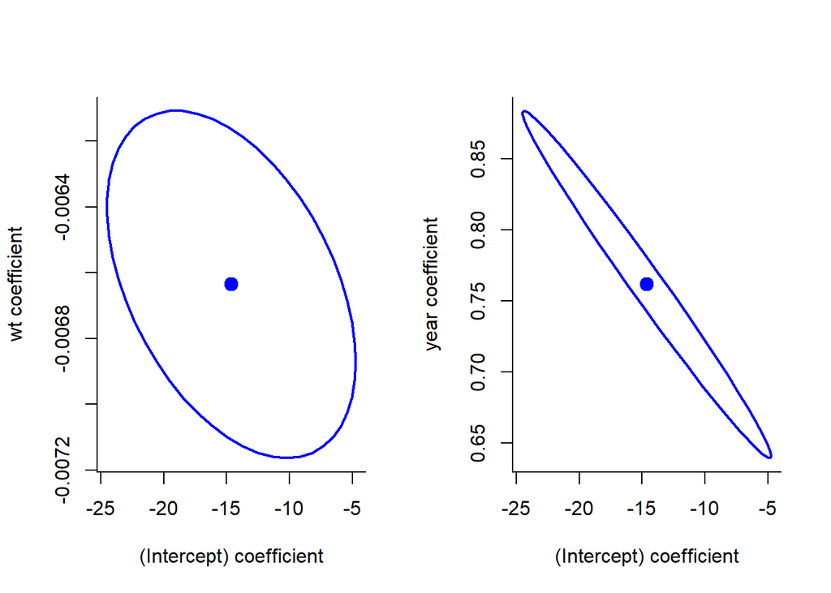

```r
par(bty = "l", mfrow=c(1,2))
car::confidenceEllipse(fit, which.coef=c(1,2), vcov.=vcov(fit), grid = FALSE)
car::confidenceEllipse(fit, which.coef=c(1,3), vcov.=vcov(fit), grid = FALSE)
```

Come viene costruita l’ellissi? La procedura è spiegata estesamente nella Lecture 18 di Cosma Shalizi’s lectures. In generale dobbiamo usare il fatto che la distribuzione chi-quadro è derivata come il quadrato di una normale e che la somma di chi-quadro segua una distribuzione chi-quadro. Indichiamo con $\mathbf{\beta}_q$ il vettore dei parametri per cui vogliamo costruire l’intervallo di confidenza, e con $\mathbf{\Sigma}_q$ la corrispondente matrice di varianza-covarianza. La regione di confidenza per $\mathbf{\beta}_q$ viene trovata come segue:
$$\begin{equation*}
(\widehat{\mathbf{\beta}}_q - \mathbf{\beta}_q)^T \mathbf{\Sigma}^{-1}_q
(\widehat{\mathbf{\beta}}_q - \mathbf{\beta}_q) \leq \chi^2_q(1-\alpha)
\end{equation*}$$
I dettagli della teoria sottostante questa derivazione non sono parte del corso..

Cio’ evidenzia pero’ che facendo una stima su un solo parametro, non si tiene conto dell’influenza della stima degli altri parametri.

# 3 Inferenza sulla funzione stimata

Confidence Intervals & Prediction Intervals

Per un dato valore di $x_i$, il valore di $y$ stimato è:

$$\hat{y}_i = \hat{\beta}_0 +
\hat{\beta}_1 x_{1i} + \ldots + \hat{\beta}_{(p-1)} x_{(p-1)i} = X
\hat{\beta} = X (X^T X) ^{-1} X^T y.$$
La matrice $H = X (X^T X) ^{-1} X^T$ viene detta la hat matrix, perché è la matrice che permette di trasformare i calori osservati $y_i$ nei corrispondenti valori stimati (hat y) $\hat{y}_i$ (`y_hat`).

```r
H <- X  %*% solve(t(X) %*% X) %*% t(X)
y_hat <- as.vector(H %*% y)
head(y_hat); head(as.vector(fit$fitted.values))
```

```
## [1] 15.411890 14.157898 15.863061 15.882966 15.776808  9.858499
```

```
## [1] 15.411890 14.157898 15.863061 15.882966 15.776808  9.858499
```

La funzione `predict` ci permette di estrarre gli intervalli di confidenza e predizione:

```r
nd <- data.frame(wt = c(1650, 3000, 5000), year = c(72, 75, 82))
(cint <- predict(fit, nd, interval = "conf"))
```

```
##        fit      lwr      upr
## 1 29.23575 28.39013 30.08138
## 2 22.56288 22.20933 22.91642
## 3 14.62294 13.39694 15.84894
```

```r
## da dove vengono questi numeri?
x0 <- cbind(rep(1,3), c(1650, 3000, 5000),c(72, 75, 82))
se_cx0 <- est_sigma * sqrt(diag(x0 %*% solve(t(X) %*% X) %*% t(x0)))
cbind(x0 %*% beta_hat + qt(0.025, n-length(beta_hat)) * se_cx0,
      x0 %*% beta_hat + qt(0.975, n-length(beta_hat)) * se_cx0)
```

```
##          [,1]     [,2]
## [1,] 28.39013 30.08138
## [2,] 22.20933 22.91642
## [3,] 13.39694 15.84894
```

```r
(pint <- predict(fit, nd, interval = "pred"))
```

```
##        fit       lwr      upr
## 1 29.23575 22.436509 36.03500
## 2 22.56288 15.807166 29.31859
## 3 14.62294  7.765993 21.47989
```

```r
## da dove vengono questi numeri?
se_px0 <- est_sigma * sqrt(1+diag(x0 %*% solve(t(X) %*% X) %*% t(x0)))
cbind(x0 %*% beta_hat + qt(0.025, n-length(beta_hat)) * se_px0,
      x0 %*% beta_hat + qt(0.975, n-length(beta_hat)) * se_px0)
```

```
##           [,1]     [,2]
## [1,] 22.436509 36.03500
## [2,] 15.807166 29.31859
## [3,]  7.765993 21.47989
```

```r
rm(se_px0, se_cx0)
```

Entrambi gli intervalli sono centrati sul valore stimato puntuale, ma gli intervalli di predizione sono sempre più ampi (c’e’ piu’ variabilita’).

```r
cint[,3] - cint[,2]
```

```
##         1         2         3
## 1.6912538 0.7070937 2.4519926
```

```r
pint[,3] - pint[,2]
```

```
##        1        2        3
## 13.59849 13.51142 13.71389
```

Notiamo anche che uno degli intervalli di confidenza è molto più largo degli altri: perché?

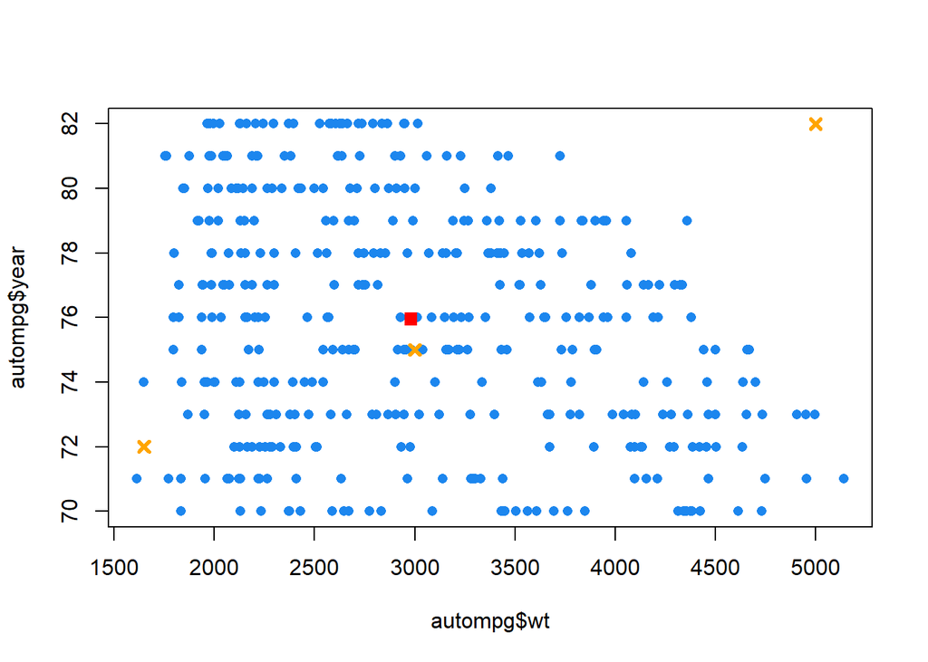

```r
plot(autompg$wt, autompg$year,pch=16,col="dodgerblue2")
points(nd, pch =4, col="orange",lwd=3)
points(mean(autompg$wt), mean(autompg$year), pch = 15, col="red",cex=1.3)
```

C’è più incertezza nella stima di punti distanti dal valore $(\bar{x}_1, \bar{x}_2)$ e in generale per i punti lontani dai valori osservati nel dataset. Infatti, il grafico evidenzia che:

- Il punto estrapolato in alto a destra e’ ha una varianza altissima
- Il punto vicino alla media, ha la varianza piu’ bassa
- Il punto in basso a sinistra, e’ un po’ estremo sebbene abbia come supporto delle osservazioni. Infatti, ha comunque una varianza relativamente alta.

# 4 Visualizzare la stima

Come possiamo visualizzare i valori stimati di $y_i$? Facciamo un primo tentativo:

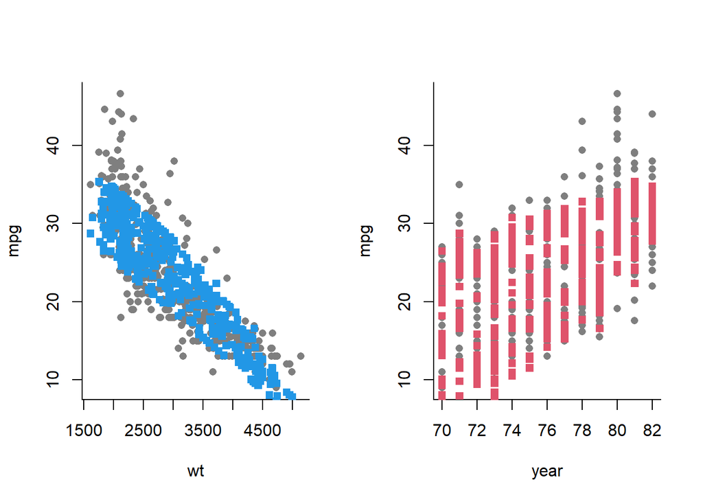

```r
par(mfrow=c(1,2), bty="l",pch=16)
plot(mpg~wt, data= autompg,col="grey50")
points(autompg$wt, y_hat, col = 4, pch = 15)
plot(mpg~year, data= autompg,col="grey50")
points(autompg$year, y_hat, col = 2, pch = 15)
```

Non esattamente chiaro…

I valori stimati dipendono dalla combinazione dei valori osservati di `wt` e `year`, quindi la relazione stimata tra una variabile esplicativa e $Y$ che vediamo è “sporcata” dalla dipendenza con l’altra variabile. Non possiamo più usare semplicemente `abline` per fare un grafico che mostri la relazione: dobbiamo in qualche modo “fissare” il valore dell’altra variabile. Questo si può fare usando la funzione `predict` (o approcci simili). Possiamo quindi mostrare la retta che mostri la relazione tra `wt` e `mpg` *tendendo fisso il valore di `year`* e viceversa. Similmente, possiamo mostrare come `year` impatti `mpg` per determinati valori di `wt`:

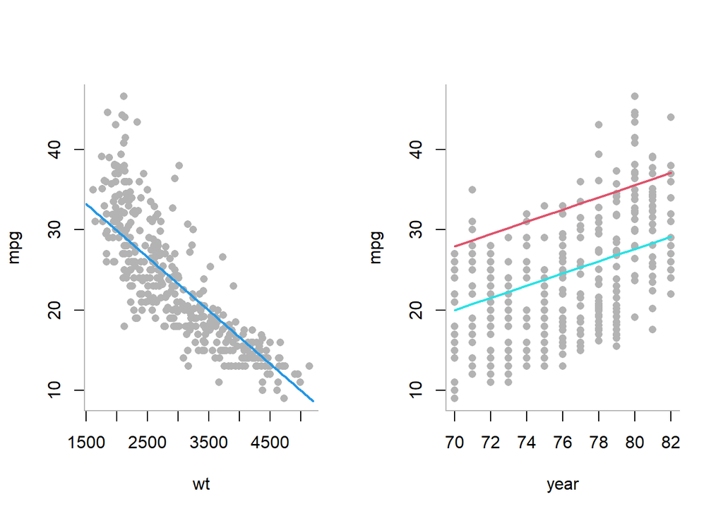

```r
par(mfrow=c(1,2), bty="l",pch=16,col="grey70")
plot(mpg~wt, data= autompg)
nd <- data.frame(wt = seq(1500, 5200, length.out = 100), year = mean(autompg$year))
lines(nd$wt, predict(fit, nd), lwd=2,col=4)
plot(mpg~year, data= autompg)
## an "X" matrix but with one column with fixed values
Xfix <- cbind(rep(1,n),rep(min(autompg$wt)),autompg$year)
lines(autompg$year, Xfix %*% coef(fit), lwd = 2 , col = 2)
Xfix <- cbind(rep(1,n),rep(median(autompg$wt)),autompg$year)
lines(autompg$year, Xfix %*% coef(fit), lwd = 2 , col = 5)
```